# Project: Investigate a TMDb (The Movie Database) dataset

This data set contains information about 10,000 movies collected from The Movie Database (TMDb), including user ratings and revenue.

- Introduction
- Data Wrangling
- Exploratory Data Analysis
- Conclusions

## Introduction

This data set contains information of about 10,000 movies, collected from The Movie Databse(TMDb). It contains information regarding the cast, director, production company, release date, revenue, ratings, genre, playtime and more.

**Questions for research**

- Which are the most popular, and least popular genres based on the number of movies in each genre in our database
- How have user ratings for movies in popoular genres, changed over 10 year periods. Keeping in mind the the average rating of movies falling in the studied genres in the 10 year periods.
- How have the user ratings for popular genres changed over these periods, keeping in mind the average user sentiment for each genre over 50 years.
- How have the profits for movies in popular genres, changed over 10 year periods in our database.

> Dependent Variable: YEARBINS

> a : 1960-1969 b : 1970-1979 c : 1980-1989 d : 1990-1999 e : 2000-2009 f : 2010-2019

> Independent Variables: Ratings of popular genres over yearbins.

Importing packages to be used during the analysis.

```python
#import statements for packages used

import matplotlib.pyplot as plt
%matplotlib inline

import numpy as np
import pandas as pd
import seaborn as sns
import time
```

## Data Wrangling

### General Properties

> **Loading in the 'tmdb-movies.csv' file, and printing out a few lines, and checking the total length.**

```python
#Load Data and print few lines
tmdb_df = pd.read_csv('tmdb-movies.csv')
print tmdb_df.head()
print len(tmdb_df) #1086
```

```
       id    imdb_id  popularity     budget     revenue  \
0  135397  tt0369610   32.985763  150000000  1513528810
1   76341  tt1392190   28.419936  150000000   378436354
2  262500  tt2908446   13.112507  110000000   295238201
3  140607  tt2488496   11.173104  200000000  2068178225
4  168259  tt2820852    9.335014  190000000  1506249360

                 original_title  \
0                Jurassic World
1            Mad Max: Fury Road
2                     Insurgent
3  Star Wars: The Force Awakens
4                     Furious 7

                                                cast  \
```

[output cut: 50 more lines]

We see that the dataframe has 21 columns of interesting information per movie. Ranging from genres to the budget adjusted for inflation. We see that there are a total of 10866 rows.

> **Inspecting data types and looking for instances of missing or possibly errant data**

```python
#making df point to tmdb_df
df = tmdb_df

#Checking for duplicate rows
print df[df.duplicated(['id'], keep=False)]
```

```
         id    imdb_id  popularity    budget  revenue original_title  \
2089  42194  tt0411951     0.59643  30000000   967000         TEKKEN
2090  42194  tt0411951     0.59643  30000000   967000         TEKKEN

                                                   cast homepage  \
2089  Jon Foo|Kelly Overton|Cary-Hiroyuki Tagawa|Ian...      NaN
2090  Jon Foo|Kelly Overton|Cary-Hiroyuki Tagawa|Ian...      NaN

              director              tagline     ...       \
2089  Dwight H. Little  Survival is no game     ...
2090  Dwight H. Little  Survival is no game     ...

                                               overview runtime  \
2089  In the year of 2039, after World Wars destroy ...      92
2090  In the year of 2039, after World Wars destroy ...      92

                                           genres    production_companies  \
2089  Crime|Drama|Action|Thriller|Science Fiction  Namco|Light Song Films
2090  Crime|Drama|Action|Thriller|Science Fiction  Namco|Light Song Films

     release_date vote_count  vote_average  release_year  budget_adj  \
2089      3/20/10        110           5.0          2010  30000000.0
2090      3/20/10        110           5.0          2010  30000000.0

      revenue_adj
2089     967000.0
2090     967000.0

[2 rows x 21 columns]
```

We see that row 2089 and 2090 have same content (id = 42194)

**Checking for NaNs and Zeros in rating column**

```python
#to check for NaN condition
def isnan(f):
    return isinstance(f, float) and f!=f

def iszero(q):
    if isnan(q):
        return False
    if q ==0:
        return True
    else:
        return False


#check if vote_average has NaN or 'zero' values

assert len(df[df.vote_average.apply(isnan)]) == 0
assert len(df[df.vote_average.apply(iszero)]) == 0
```

No NaNs or Zeros in the vote_average(rating) column

**Checking datatype for genres**

```python
#Checking datatype
print type(df['genres'][0])

#printing and seeing
print df['genres'][0] # String with '|' as delimiter.

#Checking if nans exist in column and printing occurences of nan in the column.
print len(df[df.genres.apply(isnan)])
```

```
<type 'str'>
Action|Adventure|Science Fiction|Thriller
23
```

The column genres contain strings. Genres seem to be separated with '|', acting as a delimiter. There are 23 NaN values in the genre column.

**checking revenue_adj and budget_adj for zeros and nans**

```python
print len(df[df.revenue_adj.apply(isnan)])
print len(df[df.budget.apply(isnan)])

print len(df[df.revenue_adj.apply(iszero)])
print len(df[df.budget.apply(iszero)])
```

```
0
0
6016
5696
```

Revenue_adj and budget_adj have no NaNs, but have zero values

### Data Cleaning (Performing cleaning steps)

> - Deleting duplicate row
> - Splitting single row data with multiple genres into multiple rows with single genres.

> Add yearbin column
> - a: 1960 - 1969
> - b: 1970 - 1979
> - c: 1980 - 1989
> - d: 1990 - 1999
> - e: 2000 - 2009
> - f: 2010 - 2015

**Deleting duplicate row. Keeping first occurence. Doing operation on the original dataframe.**

```python
#delete duplicate row
df.drop_duplicates(inplace=True)
len(df)  #new length - 10865
```

```
10865
```

The duplicate row has been deleted.

**Splitting single row data with multiple genres into multiple rows with single genres.**

```python
s = df['genres'].str.split('|').apply(pd.Series, 1).stack() #splitting by the delimiter '|', and stacking all of them up.
s.index = s.index.droplevel(-1) #Dropping the extra level of index
del df['genres'] #dropping original 'genres' column
s.name = 'genres' # for join to work, adding name
newdf = df.join(s)
newdf.genres.head()
```

```
0             Action
0          Adventure
0    Science Fiction
0           Thriller
1             Action
Name: genres, dtype: object
```

We see that we've successfully split multiple genre rows into single genre rows, preserving original indexing

**Adding new column for year ranges. 10 year intervals. [ 1960-1969, 1970-1979, ... and so on ]**

```python
#adding new column for year ranges


newdf['year_bin'] = pd.cut(newdf.release_year, [1960,1969,1979,1989,1999,2009,2019], \
                           include_lowest=True, labels=['a','b','c','d','e','f'] )
```

```python
newdf.year_bin.describe() #Checking if everything checks out
```

```
count     26978
unique        6
top           e
freq       9210
Name: year_bin, dtype: object
```

The new column 'year_bin' has been successfully added. with lablels a,b,c,e,d,f for 10 year intervals from 1960 to 2020

**Change all zeros to NaN values in budget_adj and revenue_adj columns**

```python
#Change all zeros to NaN values in budget_adj and revenue_adj
newdf.budget_adj = newdf.budget_adj.replace(0, np.nan)
newdf.revenue_adj = newdf.revenue_adj.replace(0, np.nan)

#Check if zeros exist

print len(newdf[newdf.revenue_adj.apply(iszero)])
print len(newdf[newdf.budget_adj.apply(iszero)])
```

```
0
0
```

Rows with zero values can be movies where budget/revenue data was not available. Zeros are made to NaNs above so that, when doing simple arithmetic calculation with these values, if value is zero (now NaN), the resulting value will also be NaN.

**Adding profit_adj column --> Profit = ( Revenue - Budget )**

```python
#Adding new column 'profit_adj'
newdf['profit_adj']=newdf.revenue_adj.sub(newdf.budget_adj, axis=0)

# replace 0 values with nans in profit_adj and roi_adj
newdf.profit_adj = newdf.profit_adj.replace(0, np.nan)
```

New column 'profit_adj' was added, and values were calculated and stored. Rows with zero values in the 'profit_adj' column was changed to NaN; on the assumption that this was some kind of data error, where profit and revenue matched up exactly .

## Exploratory Data Analysis

### Which are the most popular, and least popular genres based on the number of movies in each genre in our database

**Finding top 7 genres according to movie counts and storing them into series.**

```python
topgenres = newdf.genres.value_counts().nlargest(7)
```

```python
print topgenres
```

```
Drama        4760
Comedy       3793
Thriller     2907
Action       2384
Romance      1712
Horror       1637
Adventure    1471
Name: genres, dtype: int64
```

The top genres are Drama, Comedy, Thriller, Action, Romance, Horror and Aventure.

**Finding least popular genres**

```python
leastgenres = newdf.genres.value_counts().nsmallest(5)
```

```python
print leastgenres
```

```
Western     165
TV Movie    167
Foreign     188
War         270
History     334
Name: genres, dtype: int64
```

The least popular genres are Western, TV Movie, Foreign, War and History

### How have user ratings and profits for movies in popoular genres, changed over 10 year periods. Keeping in mind the the average rating of movies falling in the studied genres in the 10 year periods.

**Creating a histogram to see how ratings are spread in the database**

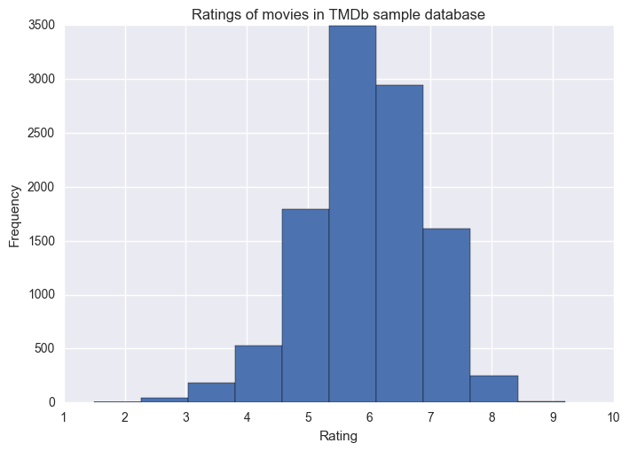

```python
histplot = df.vote_average.plot(kind='hist')
histplot.set(xlabel='Rating')
histplot.set(title='Ratings of movies in TMDb sample database')
```

We see that most of the movies are rated between 5 and 6. Around 3500 movies are present in this bin.

**Creating new dataframe containing only the top 7 genres which we are analysing**

```python
studied_df = newdf[newdf.genres.isin(topgenres.index)]
studied_df.genres.describe()
```

```
count     18664
unique        7
top       Drama
freq       4760
Name: genres, dtype: object
```

Stored new dataframe as studied_df, and checked values in 'genre' column. Everything checks out.

**Grouping by genres, and finding average rating for them from 1960-2015**

```python
groupby_genres = studied_df.groupby('genres')
avg_rating_studied_genres = groupby_genres['vote_average'].mean()
print avg_rating_studied_genres
```

```
genres
Action       5.787752
Adventure    5.940585
Comedy       5.905167
Drama        6.165546
Horror       5.337447
Romance      6.042874
Thriller     5.750671
Name: vote_average, dtype: float64
```

We see the average rating of the most popular genres across the entire study period. Interesting!

**Grouping by year_bin, and finding average rating of genres studied in each yearbin**

```python
avg_rating_yearbins = studied_df.groupby('year_bin')['vote_average'].mean()
print avg_rating_yearbins
```

```
year_bin
a    6.224626
b    6.374246
c    6.034493
d    5.954741
e    5.834079
f    5.779805
Name: vote_average, dtype: float64
```

We see the average rating of studied genres in each yearbin. Interesting! We see a gradual decline in the ratings. Maybe because the number of mediocre movies being produced in recent times have gone high, or maybe because the public is more critical, or maybe because the samples in our database is not right. So many possibilities. Interesting nonetheless!

**Using pivot_table on the dataframe, so that we get average rating of each genre in each 10 year interval being analysed.**

```python
ratings_table = studied_df.pivot_table(index='genres',columns='year_bin')['vote_average']
print ratings_table
```

```
year_bin          a         b         c         d         e         f
genres
Action     6.042308  6.371074  5.931985  5.776703  5.744615  5.653540
Adventure  6.250000  6.320779  6.048000  5.816364  5.829842  6.000267
Comedy     6.153982  6.411475  6.021729  5.913026  5.779099  5.929355
Drama      6.370833  6.512552  6.256974  6.221810  6.124396  6.070475
Horror     6.068085  6.090385  5.764706  5.469841  5.257851  5.010473
Romance    6.176119  6.380392  6.072571  6.073021  5.941390  6.093708
Thriller   6.328125  6.347973  5.995385  5.895960  5.719692  5.511606
```

The values in the table is not normalized to any baseline

**Plotting a line graph of the ratings as it is.**

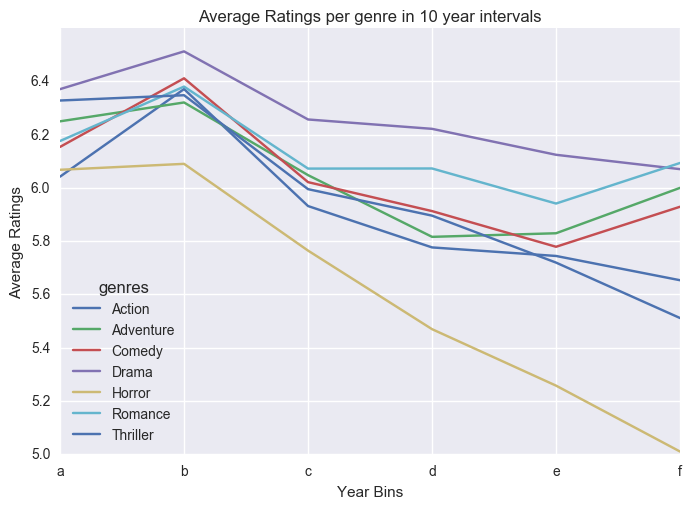

```python
plot1 = ratings_table.transpose().plot(kind='line')
plot1.set(xlabel='Year Bins', ylabel='Average Ratings')
plot1.set(title='Average Ratings per genre in 10 year intervals')
```

**LEGEND for x- axis**

> a : 1960 - 1969 b : 1970 - 1979 c : 1980 - 1989 d : 1990 - 1999 e : 2000 - 2009 f : 2010 - 2019

We see the non-standardised average rating values across the 10 year interval year bins in graphic. Clearly 'horror' genre movies are not at all doing good.

**Standardising the ratings_table with average rating of genres studied in each yearbin. (avg_rating_yearbins). Plotting the same**

```
year_bin          a         b         c         d         e         f
genres
Action    -0.182318 -0.003172 -0.102508 -0.178037 -0.089464 -0.126265
Adventure  0.025374 -0.053467  0.013507 -0.138377 -0.004237  0.220462
Comedy    -0.070643  0.037229 -0.012764 -0.041715 -0.054980  0.149550
Drama      0.146208  0.138306  0.222481  0.267069  0.290317  0.290670
Horror    -0.156541 -0.283861 -0.269787 -0.484899 -0.576228 -0.769332
Romance   -0.048506  0.006146  0.038078  0.118280  0.107311  0.313903
Thriller   0.103499 -0.026273 -0.039109 -0.058781 -0.114387 -0.268199
```

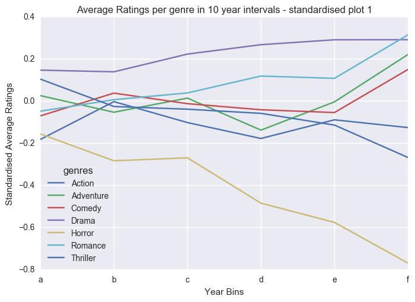

```python
std_table1 = ratings_table - avg_rating_yearbins
print std_table1

plot2 = std_table1.transpose().plot()
plot2.set(xlabel='Year Bins', ylabel='Standardised Average Ratings')
plot2.set(title='Average Ratings per genre in 10 year intervals - standardised plot 1')
```

**LEGEND for x- axis**

> a : 1960 - 1969 b : 1970 - 1979 c : 1980 - 1989 d : 1990 - 1999 e : 2000 - 2009 f : 2010 - 2019

It looks like Comedy, Adventure, and Romance, have been rated higher, compared to other top movie genres, in recent years.

### How have the user ratings for popular genres changed over these periods, keeping in mind the average user sentiment for each genre over 50 years.

**Standardising the ratings_table with average rating of movies per genre in the study period. (avg_rating_studied_genres). Plotting the same**

```
year_bin          a         b         c         d         e         f
genres
Action     0.254556  0.583323  0.144234 -0.011048 -0.043136 -0.134212
Adventure  0.309415  0.380195  0.107415 -0.124221 -0.110743  0.059683
Comedy     0.248815  0.506308  0.116562  0.007858 -0.126068  0.024188
Drama      0.205287  0.347006  0.091428  0.056264 -0.041150 -0.095071
Horror     0.730639  0.752938  0.427259  0.132395 -0.079595 -0.326974
Romance    0.133246  0.337518  0.029698  0.030147 -0.101484  0.050834
Thriller   0.577454  0.597302  0.244714  0.145289 -0.030978 -0.239065
```

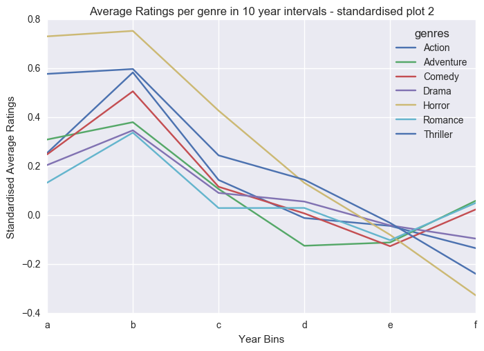

```python
std_table2 = ratings_table.sub(avg_rating_studied_genres, axis=0)
print std_table2

plot3 = std_table2.transpose().plot()
plot3.set(xlabel='Year Bins', ylabel='Standardised Average Ratings')
plot3.set(title='Average Ratings per genre in 10 year intervals - standardised plot 2')
```

**LEGEND for x- axis**

> a : 1960 - 1969 b : 1970 - 1979 c : 1980 - 1989 d : 1990 - 1999 e : 2000 - 2009 f : 2010 - 2019

### How have the profits for movies in popular genres, changed over 10 year periods in our database.

**Using pivot_table on the dataframe, getting mean of profits_adj column of movies in each popular genres, in each yearbin.**

```python
profits_table = studied_df.pivot_table(index='genres', columns = 'year_bin')['profit_adj']
print profits_table
```

```
year_bin              a             b             c             d  \
genres
Action     2.862151e+08  2.732464e+08  1.484618e+08  1.071514e+08
Adventure  3.731616e+08  3.440078e+08  1.742458e+08  1.351785e+08
Comedy     2.446660e+08  1.894247e+08  1.012396e+08  8.496413e+07
Drama      1.958840e+08  2.374316e+08  8.239464e+07  8.340649e+07
Horror     1.239512e+08  3.549121e+08  4.184384e+07  3.863651e+07
Romance    2.695962e+08  1.445067e+08  9.955062e+07  1.090440e+08
Thriller   3.343895e+08  2.949908e+08  7.422855e+07  9.654112e+07

year_bin              e             f
genres
Action     1.041820e+08  1.423650e+08
Adventure  1.598114e+08  2.366648e+08
Comedy     6.944267e+07  7.679938e+07
Drama      4.543655e+07  4.469981e+07
Horror     5.066290e+07  4.382695e+07
Romance    5.926542e+07  5.823950e+07
Thriller   5.950906e+07  6.888591e+07
```

The profits_table looks right.

**Plotting the table**

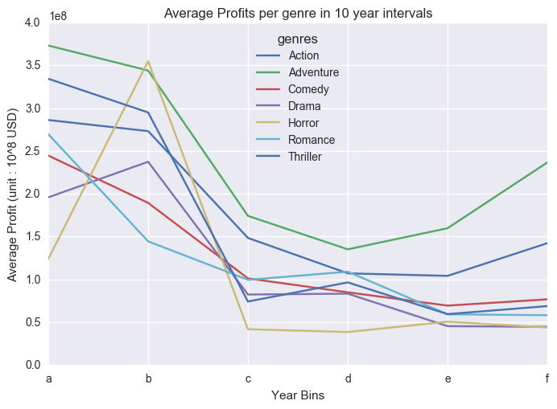

```python
profits_plot = profits_table.transpose().plot()
profits_plot.set(xlabel='Year Bins', ylabel='Average Profit (unit : 10^8 USD)')
profits_plot.set(title='Average Profits per genre in 10 year intervals')
```

**LEGEND for x- axis**

> a : 1960 - 1969 b : 1970 - 1979 c : 1980 - 1989 d : 1990 - 1999 e : 2000 - 2009 f : 2010 - 2019

**Checking horror movie with high profit**

```python
for i, k in studied_df.groupby('genres'):
    if i == 'Horror':
        print k[k.profit_adj.isin(k.profit_adj.nlargest(5))]
```

```
          id    imdb_id  popularity     budget    revenue    original_title  \
7392    6479  tt0480249    2.692916  150000000  585349010       I Am Legend
9613   10998  tt0093010    0.865813   14000000  320145693  Fatal Attraction
9806     578  tt0073195    2.563191    7000000  470654000              Jaws
10594   9552  tt0070047    2.010733    8000000  441306145      The Exorcist
10756    579  tt0077766    1.562700   20000000  187884007            Jaws 2

                                                    cast  \
7392   Will Smith|Alice Braga|Charlie Tahan|Salli Ric...
9613   Michael Douglas|Glenn Close|Anne Archer|Ellen ...
9806   Roy Scheider|Robert Shaw|Richard Dreyfuss|Lorr...
10594  Linda Blair|Max von Sydow|Ellen Burstyn|Jason ...
10756  Roy Scheider|Lorraine Gary|Murray Hamilton|Jos...

                                 homepage          director  \
```

[output cut: 35 more lines]

## Conclusions

**Limitations:**

- The database is just a sample. We dont have all movies from 1960-2015. Sample may not be the best estimate of the population.
- Rows for which values were missing, were removed from all calculations.

We see that the most popular genres according to movies appearing in the database are : Drama Comedy Thriller Action and Romance. The least popular being : Western, TV Movie, and Foreign.